# COVID Survival

DI Dr. Florian Klinglmueller

4/5/2020

# Estimating a competing risk model for recovery/death from COVID-19

**This is work very much in process - lately I find little time to work on this; explainer and more insights about the procedure are to be posted soon, hopefully**

## Introduction

One of the main challenges in estimating of the case fatality rate during an ongoing epidemic like COVID-19 is that for a large proportion of currently active cases the disease outcome of is yet unknown [Lipsitch - Important Biases][Lipsitch2015]. Simple approaches relate the number of disease related deaths to the total number of identified cases, or to the total number of cases for whom the outcome has already been observed. Whereas the former assumes that all unresolved cases recover, the latter assumes that unresolved cases recover or die at comparable rates as those for whom the outcome has already been observed. These aggregate estimators can be improved by methods from competing risk analysis, which in addition take advantage of information about the time to the outcome event. That is, a subject that has not yet recovered or died 30 days after identification, provides more information that a subject that has just recently been identified.

In order to estimate the cumulative incidence of mortality or recovery after infection as a function of time, however, we would require individual level time-to-event data. That is, data on the time from the start of infection to either recovery or death, or time of censoring for unresolved cases. Unfortunately such data are rarely available, especially not globally, much less publicly. Consequently, important disease characterstics are typically estimated from aggregate data.

While time-to-event data are hard to come by for COVID-19, well curated time-series data are available globally from various sources. While these do not provide time-to-event data, we can take advantage of information contained in the sequence of reported events. Obviously, we know that the event of a newly recorded case can only lie in the future and that save for reporting errors each event corresponds to a case detected in the past. Therefore, we randomly connect confirmed events with cases detected in the past and construct a random dataset of individual time to event data that conforms to the restrictions imposed by the temporal sequence of reported events.

We can then use standard methods from competing risks models to estimate the cumulative incidence curves for mortality and recovery.

## Implementation

Interestingly it does not appear that there is a large variability between different realizations of randomly generated time to event datasets. But, if different sampling weights are used i.e. where the propability of connecting an recent event to a past confirmed case is a function of the time difference (e.g. gamma, or exponential distribution) cummulative incidence functions differ as well. Nevertheless, the effect on estimates of mortality and recovery rates past a certain time since detection as well as limit CFR are by and large not excessive. Here I only provide estimates using uniform sampling as weighted sampling takes to long for regular updates.

What I do see is that such estimated mortality rates but also recovery rates typically far exceed naive estimators that divide the number of deaths or recovered by the number of cases. This is because the model assumes that unresolved cases have similar mortality/recovery rates as resolved cases. However, compared to aggregate rate estimates that divide by the number of resolved cases, mortality and recovery rates obtained from models are typically smaller.

## Future Improvements

While estimates are not substantially variable across samples, things do vary. E.g. for Austria I get limit mortality rates about between 3% and 4%. Also the curves often vary at the end, were the (artificial) number at risk gets small. So it would certainy be interesting to resample a couple of datasets an take an average and also quantify the variability.

Weighted sampling would definitely be interesting. Currently for a given event, all cases in the past, that have not yet been allocated are equally likely selected. Actually, given that the number of new cases per day increases (typically) it is more probably that a case closer to the event is chosen compared to one further away. I have already implemented weighting function, but it increases computation time and I have not yet determined a plausible weighting function. Exponential weighting, does not lead to substantial changes in the results.

For countries with regional data available one could further restrict within region. This would in theory be even closer to reality. However, from experience in Austria I assume that also data quality would decline as regional reporting practices may differ and be more error prone than national aggregates.

## Results

We start with China and South Korea which have only few unresolved cases.

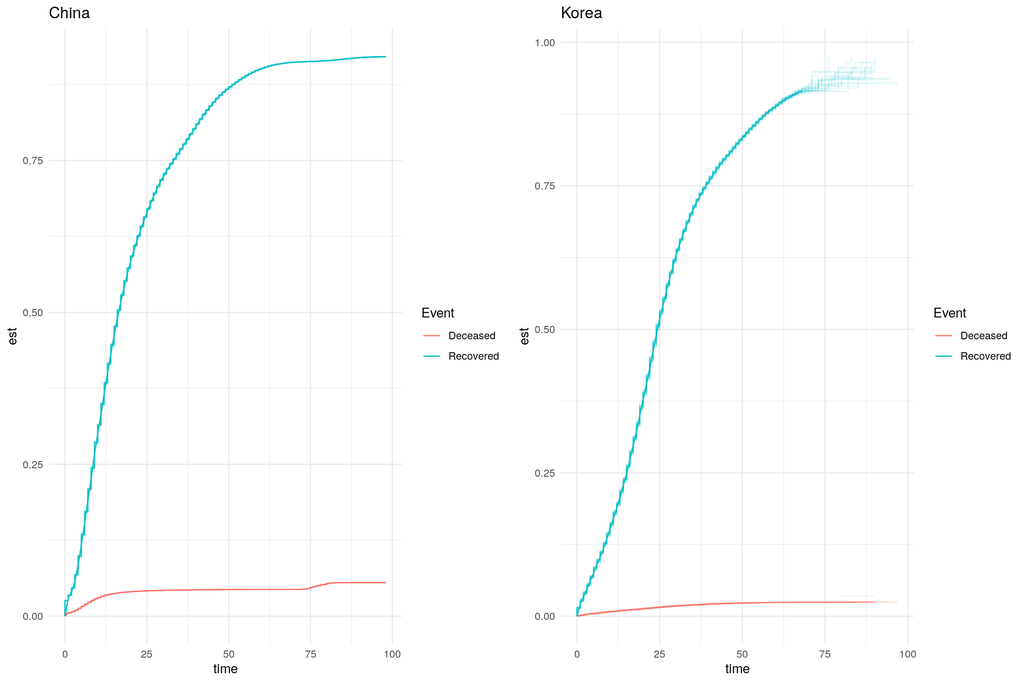

## Europe

Next we move to Europe where we look at Austria, Sweden, Germany and Italy:

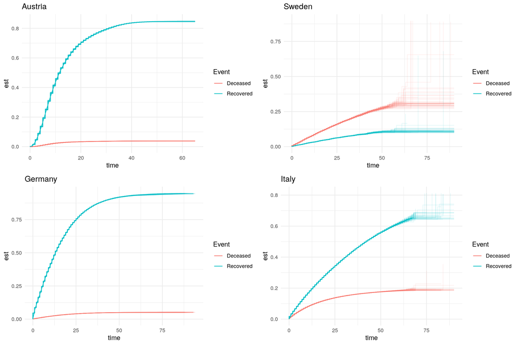

Overall we see that Austria, Germany, and Korea show quite similar characteristics. One reason may be that those countries appear to be testing quite a lot of subjects, whereas Italy and Sweden are more focused on severe/hospitalized cases in their testing programs.

## Limitations

One needs to be aware of the rather strong limitations underlying the analyses presented here. First, the disease characteristics modelled here are conditional on being identified as a case. We can be confident that the different national testing programmes do not produce unbiased estimates of the true prevalence. Moreover, testing programmes differ substantially between countries. Some countries perform comprehensive widespread testing whereas others limit testing to the relatively obvious/severe cases. In addition, we know that data on dates are far from accurate. The data are essentially left censored as we do not really know the time of infection, or onset of symptoms, which would be much more relevant starting points for this analysis. It has been reported that deceased subjects are often reported only with substantial delay, and time of recovery is difficult to pinpoint exactly and is defined in various ways (a couple of days after symptoms stop, two negative test, …).

## References

[Farley2001]: Farley, Timothy MM, Mohamed M. Ali, and Emma Slaymaker. “Competing approaches to analysis of failure times with competing risks.” Statistics in medicine 20.23 (2001): 3601-3610.

[Jewel2007]: Jewell, Nicholas P., et al. “Non‐parametric estimation of the case fatality ratio with competing risks data: an application to Severe Acute Respiratory Syndrome (SARS).” Statistics in medicine 26.9 (2007): 1982-1998.

[Tuite2010] Tuite, Ashleigh R., et al. “Estimated epidemiologic parameters and morbidity associated with pandemic H1N1 influenza.” Cmaj 182.2 (2010): 131-136.

[Lipsitsch2015]: Lipsitch, Marc, et al. “Potential biases in estimating absolute and relative case-fatality risks during outbreaks.” PLoS neglected tropical diseases 9.7 (2015).